# EFA for parent scales

# p-t rel

En esta escuela, siento que hay por lo menos un maestro… 64. … que se preocupa por mi joven. _____ 65. … quien está interesado en conocerme _____ 66. … con quien me siento/a cómodo/a hablando sobre mi joven. _____ 67. … de quien puedo hacer preguntas o hacer sugerencias sobre mi joven. _____

## The scale to factor analyze

```r
pt_rel <- parent_w1 %>%
  select(q64, q65, q66, q67)
```

## kmo Kaiser-Meyer-Olkin

```r
KMO(pt_rel) # 0.77
```

```
## Kaiser-Meyer-Olkin factor adequacy
## Call: KMO(r = pt_rel)
## Overall MSA =  0.77
## MSA for each item =
##  q64  q65  q66  q67
## 0.88 0.90 0.71 0.71
```

## Poly corr matrix

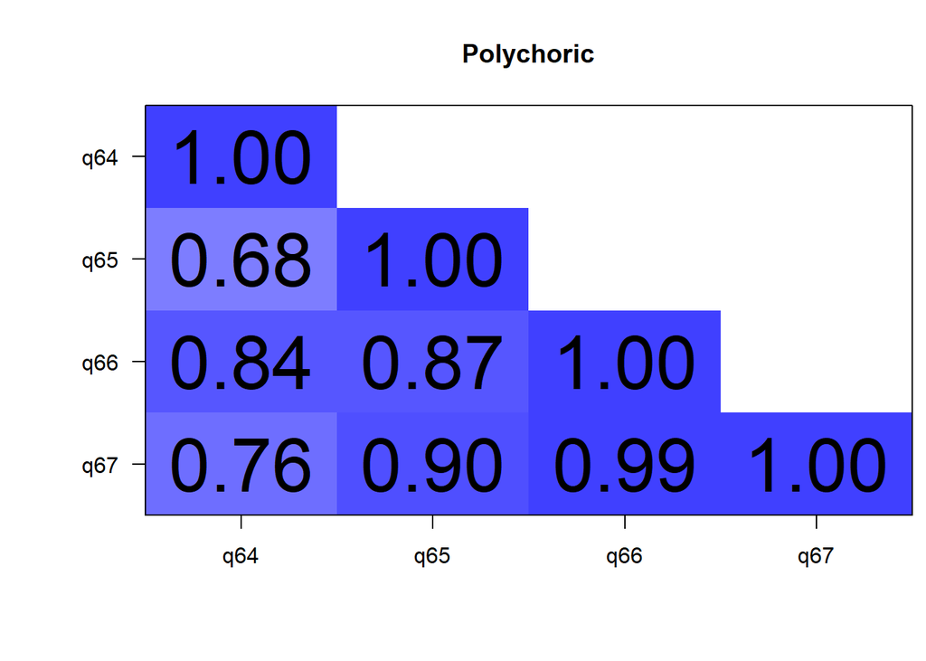

```r
poly <- polychoric(pt_rel)
cor.plot(poly$rho, numbers = T, upper = F, main = "Polychoric", show.legend = F) # very high corrs - prob multicollinearity
```

## scree plot

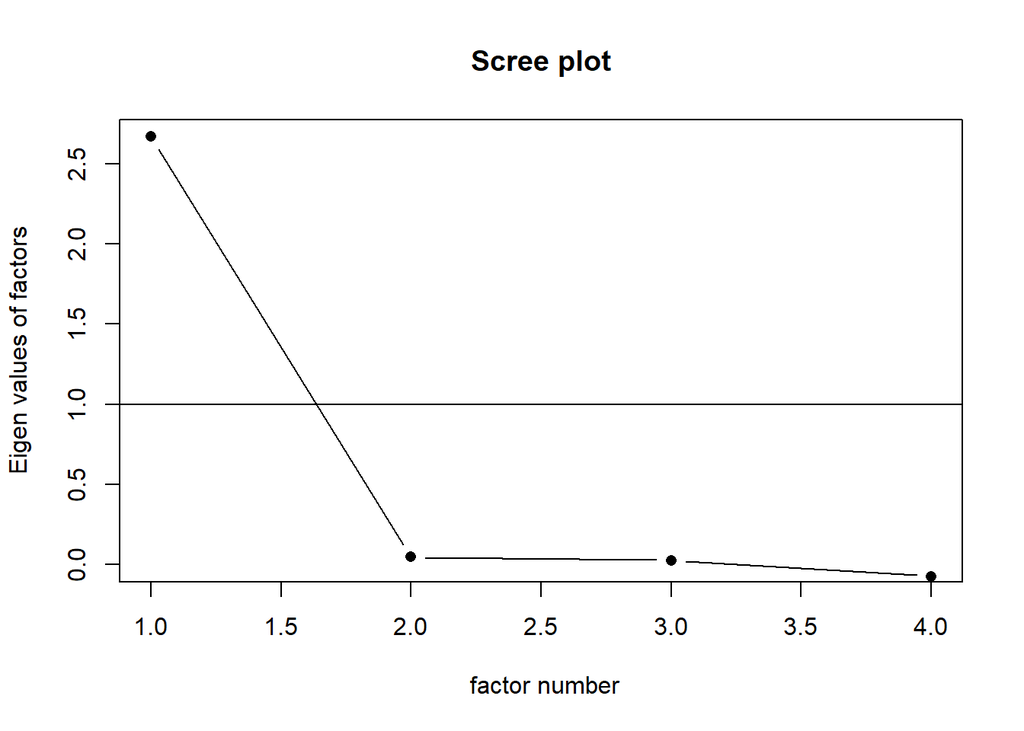

```r
scree(pt_rel, factors = TRUE, pc = FALSE, main = "Scree plot", hline = NULL, add = FALSE)
```

```r
# Scree plot clearly shows 1 factor solution
```

## parallel test

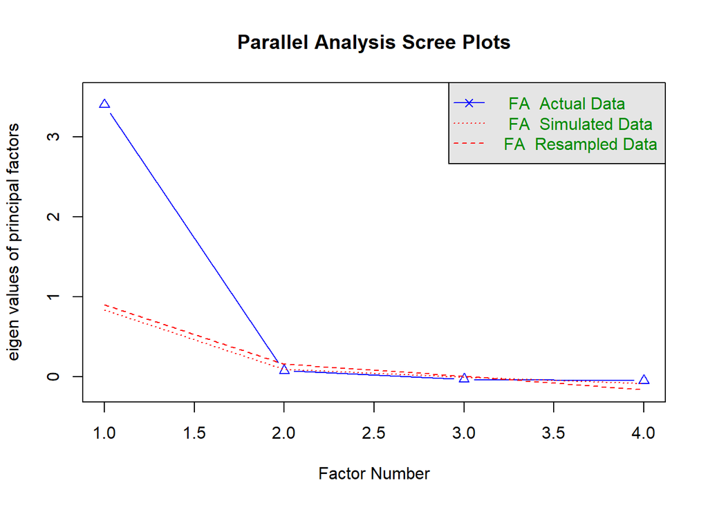

```
## Parallel analysis suggests that the number of factors =  1  and the number of components =  NA
```

```r
fa.parallel(pt_rel, n.obs=NULL, fm="uls", fa="fa", main="Parallel Analysis Scree Plots", cor="poly", use="pairwise", plot=TRUE)
```

```r
# Parallel analysis suggests that the number of factors =  1
# warnings: matrix not positive definitive
```

## EFA using ULS

```r
factor_test_uls <- fa(pt_rel, n.obs = 95, rotate = "oblimin", fm = "uls", cor = "poly", nfactors = 1)
factor_test_uls
```

```
## Factor Analysis using method =  uls
## Call: fa(r = pt_rel, nfactors = 1, n.obs = 95, rotate = "oblimin",
##     fm = "uls", cor = "poly")
## Standardized loadings (pattern matrix) based upon correlation matrix
##     ULS1   h2     u2 com
## q64 0.79 0.63  0.370   1
## q65 0.88 0.78  0.225   1
## q66 1.01 1.01 -0.011   1
## q67 0.99 0.98  0.017   1
##
##                ULS1
## SS loadings    3.40
## Proportion Var 0.85
##
## Mean item complexity =  1
## Test of the hypothesis that 1 factor is sufficient.
##
## df null model =  6  with the objective function =  24.95 with Chi Square =  2291.65
## df of  the model are 2  and the objective function was  20.18
##
## The root mean square of the residuals (RMSR) is  0.03
## The df corrected root mean square of the residuals is  0.05
##
## The harmonic n.obs is  92 with the empirical chi square  0.83  with prob <  0.66
## The total n.obs was  95  with Likelihood Chi Square =  1839.35  with prob <  0
##
## Tucker Lewis Index of factoring reliability =  -1.429
## RMSEA index =  3.11  and the 90 % confidence intervals are  3.007 3.247
## BIC =  1830.24
## Fit based upon off diagonal values = 1
```

```r
# Matrix was not positive definite
```

## removing item 66 loading > 1

```r
pt_rel <- parent_w1 %>%
  select(q64, q65, q67)
```

## without item 66

```r
factor_test_uls <- fa(pt_rel, n.obs = 95, rotate = "oblimin", fm = "uls", cor = "poly", nfactors = 1)
factor_test_uls
```

```
## Factor Analysis using method =  uls
## Call: fa(r = pt_rel, nfactors = 1, n.obs = 95, rotate = "oblimin",
##     fm = "uls", cor = "poly")
## Standardized loadings (pattern matrix) based upon correlation matrix
##     ULS1   h2      u2 com
## q64 0.76 0.57  0.4290   1
## q65 0.90 0.81  0.1861   1
## q67 1.00 1.00 -0.0028   1
##
##                ULS1
## SS loadings    2.39
## Proportion Var 0.80
##
## Mean item complexity =  1
## Test of the hypothesis that 1 factor is sufficient.
##
## df null model =  3  with the objective function =  2.61 with Chi Square =  240.55
## df of  the model are 0  and the objective function was  0
##
## The root mean square of the residuals (RMSR) is  0.01
## The df corrected root mean square of the residuals is  NA
##
## The harmonic n.obs is  91 with the empirical chi square  0.01  with prob <  NA
## The total n.obs was  95  with Likelihood Chi Square =  0.36  with prob <  NA
##
## Tucker Lewis Index of factoring reliability =  -Inf
## Fit based upon off diagonal values = 1
```

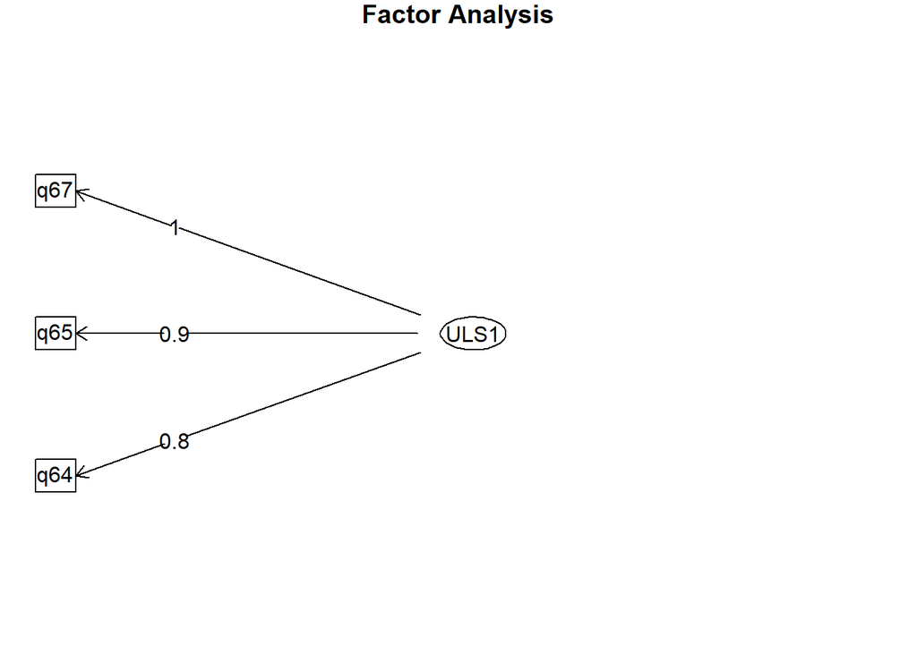

```r
fa.diagram(factor_test_uls)
```

```r
# Warnings: ultra heywood case, item 67 loading = 1
```

Conclusion: EFA not possible with this scale. However, the scale was included in multiple regression due to importance to assess parent-teacher re;ationship. Alpha is good.

```r
pt_rel <- parent_w1 %>%
  select(q64, q65, q66, q67)

alpha(pt_rel) # 0.87
```

```
##
## Reliability analysis
## Call: alpha(x = pt_rel)
##
##   raw_alpha std.alpha G6(smc) average_r S/N   ase mean   sd median_r
##       0.87      0.88    0.87      0.64 7.2 0.021  3.1 0.46     0.64
##
##     95% confidence boundaries
##          lower alpha upper
## Feldt     0.83  0.87  0.91
## Duhachek  0.83  0.87  0.91
##
##  Reliability if an item is dropped:
##     raw_alpha std.alpha G6(smc) average_r S/N alpha se  var.r med.r
## q64      0.89      0.90    0.88      0.75 9.2    0.021 0.0109  0.70
## q65      0.85      0.85    0.84      0.66 5.8    0.026 0.0356  0.59
## q66      0.80      0.80    0.74      0.57 4.0    0.035 0.0133  0.52
## q67      0.80      0.81    0.76      0.59 4.3    0.034 0.0091  0.59
##
##  Item statistics
##      n raw.r std.r r.cor r.drop mean   sd
## q64 94  0.74  0.76  0.62   0.59  3.2 0.46
## q65 90  0.85  0.84  0.76   0.70  3.0 0.56
## q66 94  0.93  0.92  0.92   0.83  3.1 0.58
## q67 93  0.91  0.90  0.90   0.82  3.1 0.50
##
## Non missing response frequency for each item
##        2    3    4 miss
## q64 0.02 0.74 0.23 0.01
## q65 0.14 0.69 0.17 0.05
## q66 0.14 0.66 0.20 0.01
## q67 0.10 0.75 0.15 0.02
```

# self-efficacy (this is an outcome in multiple regression analyses)

En general, estoy segura/o de que… 42. …yo entiendo cómo funciona la escuela de mi joven. ____ 43. …puedo comunicar mis preguntas y preocupaciones con los maestros y el personal de la escuela._ **44. …puedo trabajar con la escuela para encontrar una solución positiva si surge un conflicto o un problema que involucre a mi joven en la escuela.** _ *45. …estoy ayudando a mi joven hacer bien en la escuela.* _ **46. … estoy ayudando a mi joven prepararse para sus futuras metas de educación y carrera.** __

## The scale to factor analyze

```r
s_efficacy <- parent_w1 %>%
  select(q42, q43, q44, q45, q46)
```

## kmo Kaiser-Meyer-Olkin

```r
KMO(s_efficacy) # 0.71
```

```
## Kaiser-Meyer-Olkin factor adequacy
## Call: KMO(r = s_efficacy)
## Overall MSA =  0.71
## MSA for each item =
##  q42  q43  q44  q45  q46
## 0.74 0.66 0.71 0.68 0.81
```

## Poly corr matrix

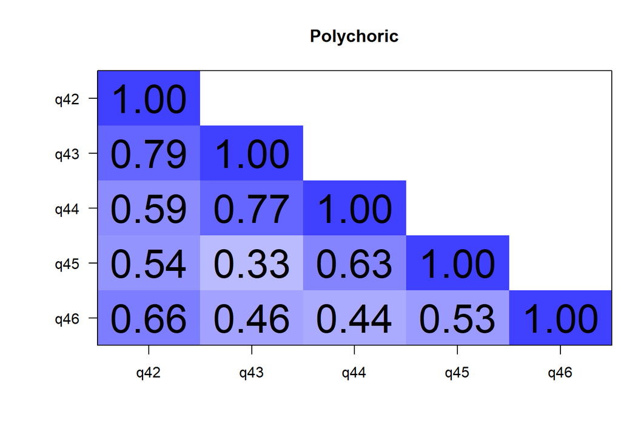

```r
poly <- polychoric(s_efficacy)
cor.plot(poly$rho, numbers = T, upper = F, main = "Polychoric", show.legend = F) # all healthy corrs
```